# Principal Component Analysis (PCA)

We will use the `USArrests` data (which is in R)

`USArrests` data is a data frame with 50 observations on 4 variables.

[,1] Murder (Numeric): Murder arrests (per 100,000)

[,2] Assault (Numeric):Assault arrests (per 100,000)

[,3] UrbanPop (Numeric): Percent urban population

[,4] Rape (Numeric): Rape arrests (per 100,000)

```r
head(USArrests)
```

```
##            Murder Assault UrbanPop Rape
## Alabama      13.2     236       58 21.2
## Alaska       10.0     263       48 44.5
## Arizona       8.1     294       80 31.0
## Arkansas      8.8     190       50 19.5
## California    9.0     276       91 40.6
## Colorado      7.9     204       78 38.7
```

```r
dimnames(USArrests)
```

```
## [[1]]
##  [1] "Alabama"        "Alaska"         "Arizona"        "Arkansas"
##  [5] "California"     "Colorado"       "Connecticut"    "Delaware"
##  [9] "Florida"        "Georgia"        "Hawaii"         "Idaho"
## [13] "Illinois"       "Indiana"        "Iowa"           "Kansas"
## [17] "Kentucky"       "Louisiana"      "Maine"          "Maryland"
## [21] "Massachusetts"  "Michigan"       "Minnesota"      "Mississippi"
## [25] "Missouri"       "Montana"        "Nebraska"       "Nevada"
## [29] "New Hampshire"  "New Jersey"     "New Mexico"     "New York"
## [33] "North Carolina" "North Dakota"   "Ohio"           "Oklahoma"
## [37] "Oregon"         "Pennsylvania"   "Rhode Island"   "South Carolina"
## [41] "South Dakota"   "Tennessee"      "Texas"          "Utah"
## [45] "Vermont"        "Virginia"       "Washington"     "West Virginia"
## [49] "Wisconsin"      "Wyoming"
##
## [[2]]
## [1] "Murder"   "Assault"  "UrbanPop" "Rape"
```

The *apply()* function allows us to apply a formula. Let’s use this to calculate the mean and variance.

Note: The second input here denotes whether we wish to compute the mean of the rows (1) or the columns (2).

```r
apply(USArrests,2,mean)
```

```
##   Murder  Assault UrbanPop     Rape
##    7.788  170.760   65.540   21.232
```

```r
apply(USArrests,2, var)
```

```
##     Murder    Assault   UrbanPop       Rape
##   18.97047 6945.16571  209.51878   87.72916
```

We see that `Assault` has a much larger variance than the other variables. It would dominate the principal components, so we choose to **standardize** the variables to have mean 0 and SD 1 when we perform PCA.

We now perform Principal Components Analysis using the **prcomp()** function

```r
pca.out=prcomp(USArrests, scale=TRUE)
```

Let’s examine the **pca.out** object. Some observations:

- Standard Deviation is the SD of the Principal Components. NOTE how they are all decreasing.
- Rotation refers to the loadings. e.g. First principal component is loaded almost equally across all compnents (like an average across all 3).
- PCA doesn’t care about the signs - all about the variance
- First Principal component focuses on crime
- Second principal component focuses on urban pop

```r
pca.out
```

```
## Standard deviations (1, .., p=4):
## [1] 1.5748783 0.9948694 0.5971291 0.4164494
##
## Rotation (n x k) = (4 x 4):
##                 PC1        PC2        PC3         PC4
## Murder   -0.5358995  0.4181809 -0.3412327  0.64922780
## Assault  -0.5831836  0.1879856 -0.2681484 -0.74340748
## UrbanPop -0.2781909 -0.8728062 -0.3780158  0.13387773
## Rape     -0.5434321 -0.1673186  0.8177779  0.08902432
```

Let’s get a summary of the object

```r
summary(pca.out)
```

```
## Importance of components:
##                           PC1    PC2     PC3     PC4
## Standard deviation     1.5749 0.9949 0.59713 0.41645
## Proportion of Variance 0.6201 0.2474 0.08914 0.04336
## Cumulative Proportion  0.6201 0.8675 0.95664 1.00000
```

Now, let’s look at a scree plot. This plots the variance explained by the principal components.

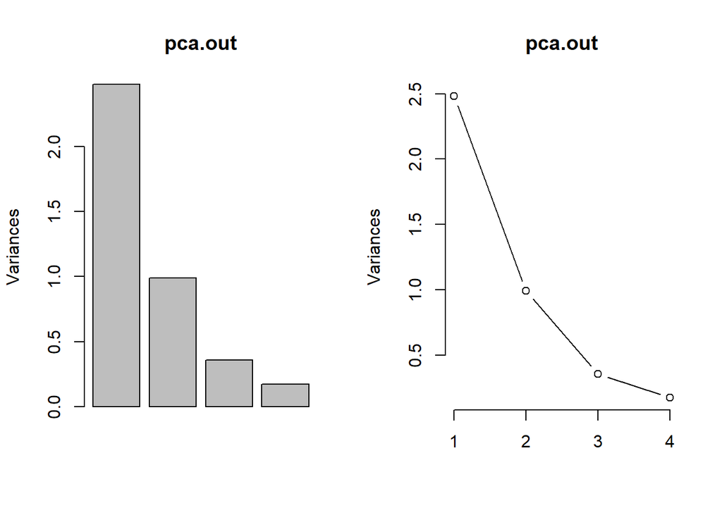

```r
layout(matrix(1:2, ncol=2))
screeplot(pca.out)
screeplot(pca.out, type="lines")
```

Plot the “Percentage of variance Explained” (PVE) of each principal component (i.e. a scree plot) and the cumulative PVE of each principal component. This can be done with just a little work.

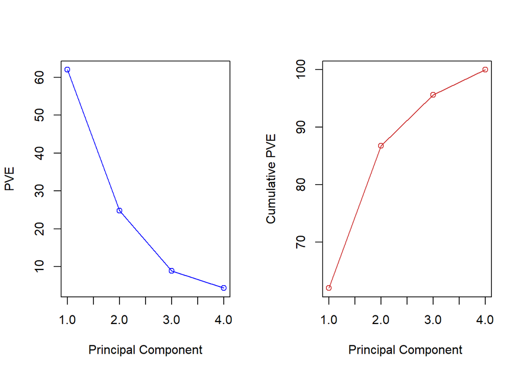

```r
pve=100*pca.out$sdev^2/sum(pca.out$sdev^2)
par(mfrow=c(1,2))
plot(pve, type="o", ylab="PVE", xlab="Principal Component",col =" blue")
plot(cumsum(pve), type="o", ylab="Cumulative PVE", xlab="Principal Component ", col =" brown3 ")
```

Finally, let’s plot the first two principal components and analyse the output

- Biplot: Both the loadings/ principal component scores and the observations (i.e. states) are in the one plot
- Observations are the states
- Red shows the directions of the loadings for the principal components.
- First Axis - largely related to the amount of crime in the state
- Second Axis - loading is mainly urban population, so this axis is whether state has large urban population or not.

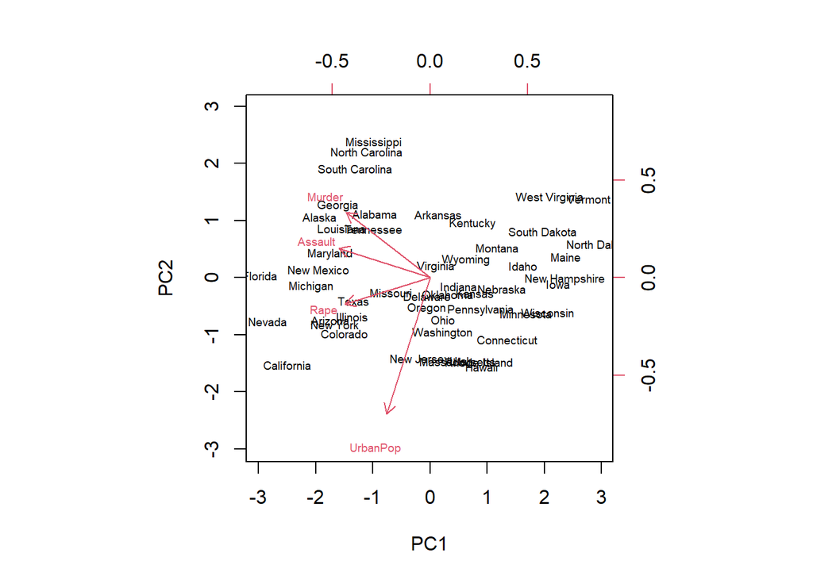

```r
biplot(pca.out, scale=0, cex = 0.6)
```